# Visualisasi Data dengan `ggplot2`

## 4.3 Direct annotation and thresholds

Legends are hard for audiences. Aligning values with important thresholds described in a figure captions is hard for audiences. It’s not always possible, but depending on your presentation and the audience, consider adding direct annotation and thresholds to plots.

We’ll do that with a few little tools:

- `annotate()`: add annotation manually by location
- `geom_hline()`: add a horizontal line
- `geom_vline()`: add a vertical line

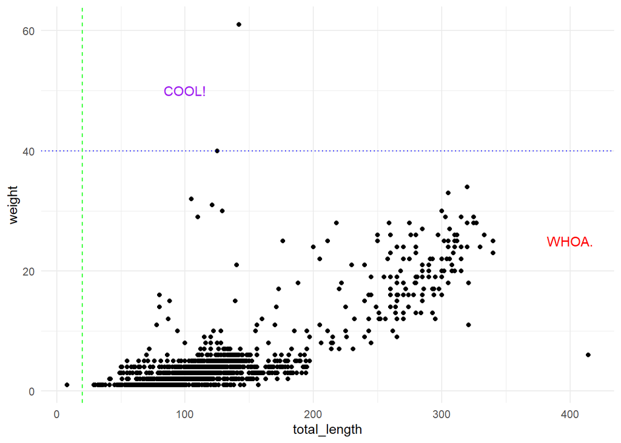

```r
p +
  annotate("text", x = 100, y = 50, label = "COOL!", color = "purple") +
  annotate("text", x = 400, y = 25, label = "WHOA.", color = "red") +
  geom_hline(yintercept = 40, linetype = "dotted", color = "blue") +
  geom_vline(xintercept = 20, linetype = "dashed", color = "green") +
  theme_minimal()
```

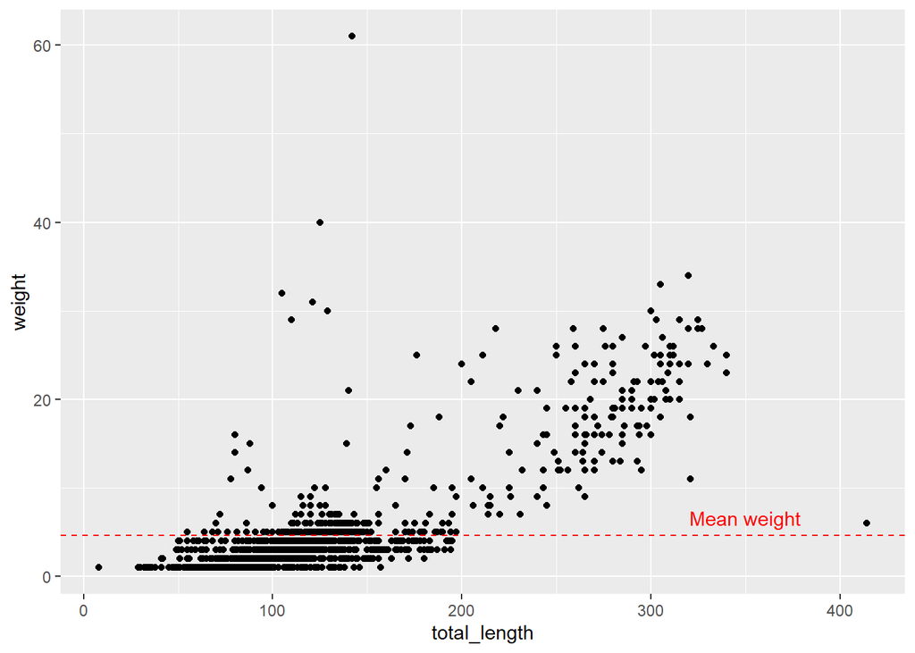

```r
# Or, have the value be determined based on a variable:
p +
  geom_hline(yintercept = mean(lizards$weight), linetype = "dashed", color = "red") +
  annotate("text", x = 350, y = mean(lizards$weight) + 2, label = "Mean weight", color = "red")
```

### 4.3.1 Apply what we’ve learned to something new!

This data is from the [Mono Basin Clearinghouse](http://monobasinresearch.org/), and contains lake level (feet above sea level) for Mono Lake - a terminal saline lake in eastern California.

Here are some important things to know when considering how to make our data viz:

- LA Department of Water & Power took water unrestricted from streams feeding into Mono Lake starting in 1941
- Unrestricted water diversions continued until the landmark 1983 California Supreme Court decision, led by the Mono Lake Committee, that “The public trust … is an affirmation of the duty of the state to protect the people’s common heritage of streams, lakes, marshlands and tidelands…”
- From *The Mono Basin Ecosystem: Effects of Changing Lake Level, published in 1987 by the Mono Basin Ecosystem Study Committee, Board on Environmental Studies and Toxicology*: “If the lake fell to levels at which the birds’ food sources were adversely affected, the bird populations would be reduced. The decrease in availability of brine shrimp for food would begin to affect those birds relying on them – eared grebes and California gulls – at a salinity of 120 g/L (lake level of 6360 ft).”

```r
# Read in the data:
mono <- read_csv(here("data_tidy", "mono.csv"))
```

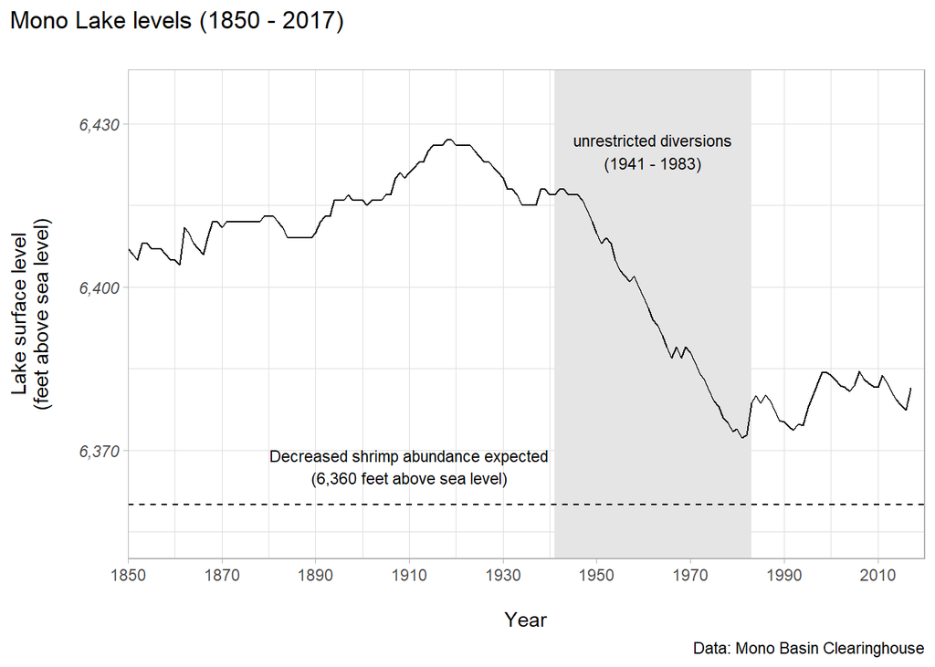

```r
ggplot(data = mono, aes(x = year, y = lake_level)) +
  geom_rect(aes(xmin = 1941,
                xmax = 1983,
                ymin = 6350,
                ymax = 6440),
            fill = "gray90") +
  geom_line() +
  labs(x = "\nYear",
       y = "Lake surface level\n(feet above sea level)\n",
       title = "Mono Lake levels (1850 - 2017)\n",
       caption = "Data: Mono Basin Clearinghouse") +
  scale_x_continuous(limits = c(1850, 2020),
                     expand = c(0,0),
                     breaks = seq(1850, 2010, by = 20)) +
  scale_y_continuous(limits = c(6350, 6440),
                     breaks = c(6370, 6400, 6430),
                     expand = c(0,0),
                     labels = scales::label_comma()) +
  annotate("text", x = 1962, y = 6425,
           label = "unrestricted diversions\n(1941 - 1983)",
           size = 3) +
  theme_light() +
  theme(plot.title.position = "plot",
        axis.text.y = element_text(face = "italic")) +
  geom_hline(yintercept = 6360, linetype = "dashed") +
  annotate("text",
           x = 1910,
           y = 6367,
           label = "Decreased shrimp abundance expected\n(6,360 feet above sea level)",
           size = 3)
```

### 4.3.2 Aside: better legends

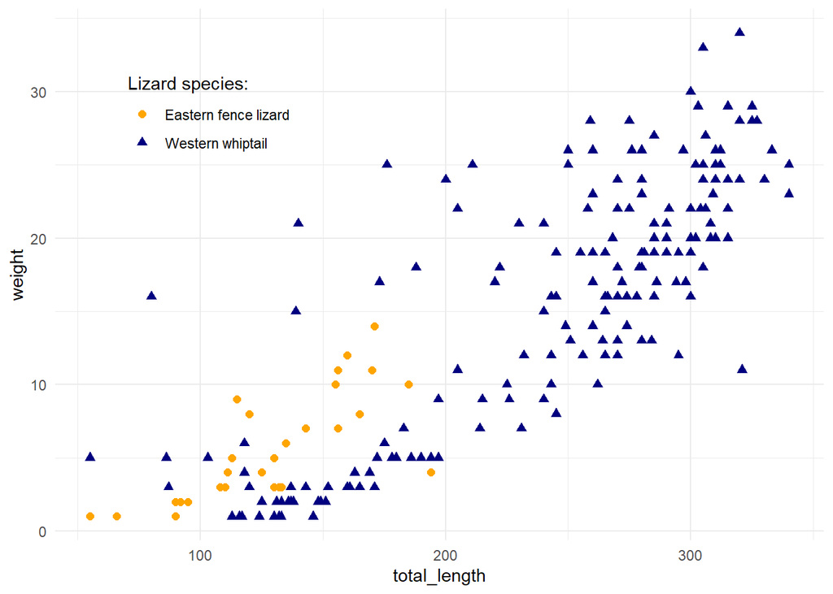

```r
two_lizards <- lizards %>%
  filter(common_name %in% c("eastern fence", "western whiptail"))

ggplot(data = two_lizards, aes(x = total_length, y = weight)) +
  geom_point(aes(color = common_name,
                 shape = common_name),
             size = 2) +
  scale_color_manual(name = "Lizard species:",
                       values = c("orange", "navy"),
                     labels = c("Eastern fence lizard", "Western whiptail")) +
  scale_shape_discrete(name = "Lizard species:",
                       labels = c("Eastern fence lizard", "Western whiptail")) +
  theme_minimal() +
  theme(legend.position = c(0.2, 0.8),
        legend.background = element_blank()) # And check out other legend.* options...it's a lot.
```

## 4.4 Repulsive labels (e.g. `ggrepel`)

Direct labeling with a bunch of groups is challenging - `ggrepel` is here to help! It makes automatic repulsive labels. Let’s make a subset of Western Whiptails at the “sand” site, then add repulsive labels by toe number.

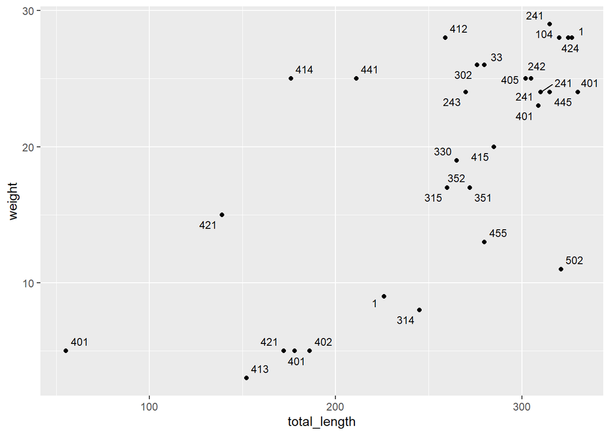

```r
wwc_lizards <- lizards %>%
  filter(common_name =="western whiptail", site == "sand")

ggplot(data = wwc_lizards, aes(x = total_length, y = weight)) +
  geom_point() +
  geom_text_repel(aes(label = toe_num), size = 3, max.overlaps = 20, show.legend = FALSE)
```

Let’s try it with a different dataset, `gapminder` (“Excerpt of the Gapminder data on life expectancy, GDP per capita, and population by country.”)

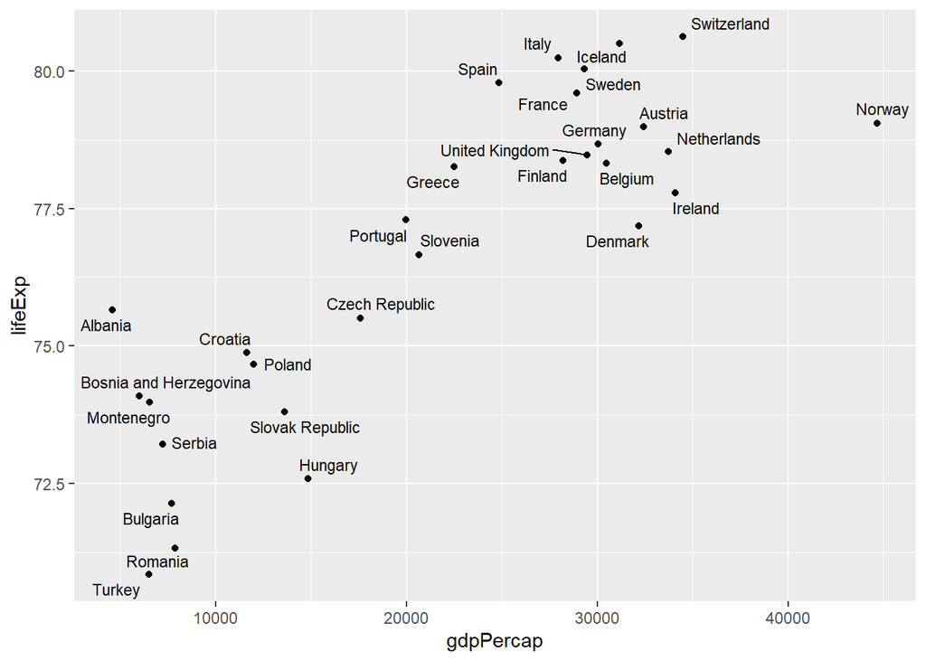

```r
gapminder %>%
  filter(year == 2002, continent == "Europe") %>%
  ggplot(aes(x = gdpPercap, y = lifeExp)) +
  geom_point() +
  geom_text_repel(aes(label = country), size = 3)
```

## 4.5 Highlighting for clarity (e.g. with `gghighlight`)

This can be particularly useful if you have made a bunch of observations or series, and you want to highlight some to make your audience’s life easier.

Add `gghighlight()` to your `ggplot` to specify highlighting conditions.

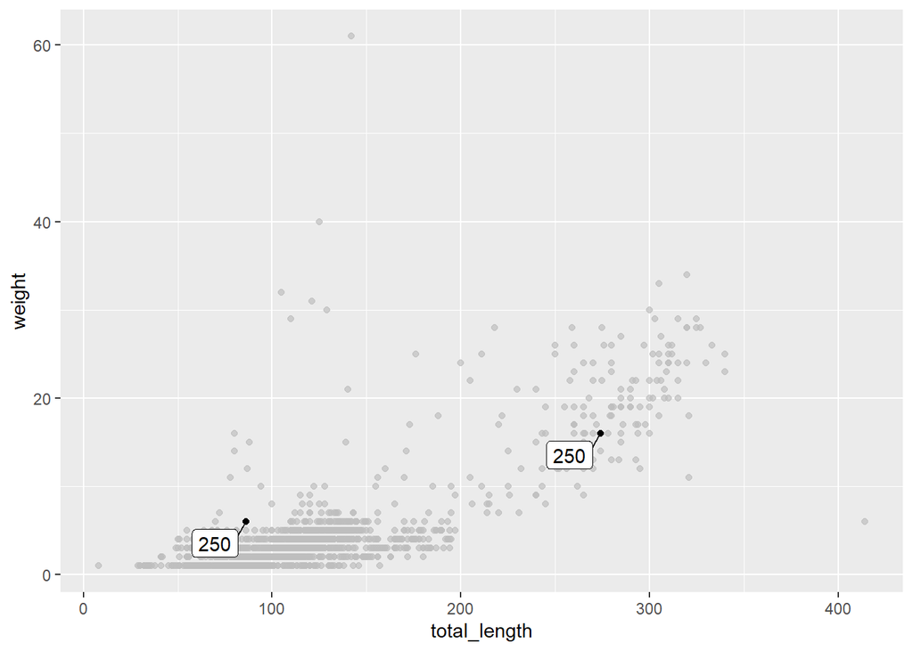

```r
p +
  gghighlight(toe_num == 250, label_key = toe_num)
```

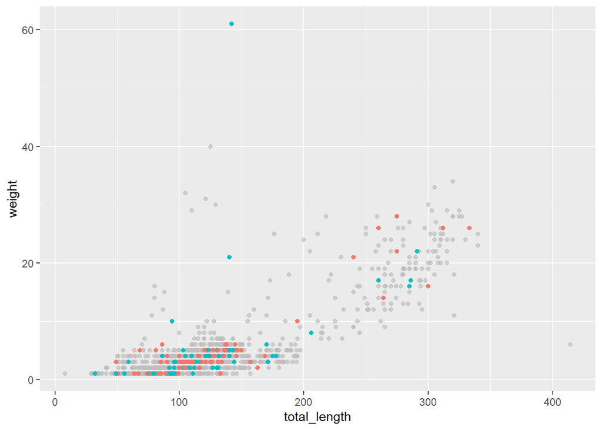

```r
p +
  aes(color = site) + # Best to include this in geom_ line instead of here...
  gghighlight(site %in% c("cali", "grav"))
```

```r
# One more example:
q <- ggplot(data = lizards, aes(x = total_length, y = weight, group = common_name)) +
  geom_line(aes(color = common_name)) +
  gghighlight(max(weight, na.rm = TRUE) > 30)
```

# 5 Compound figures with `patchwork`

Patchwork makes it easier to put multiple figures together into a single graphic – and to do some efficient theming while you’re at it.

Let’s store a couple of different graphs (we already have `p` and `q` stored):

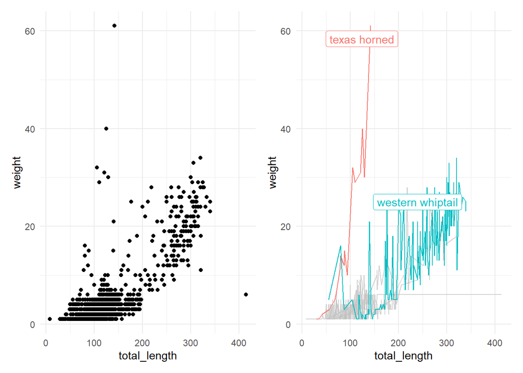

```r
(p | q) & # & means it's applied to both plots!
  theme_minimal()
```

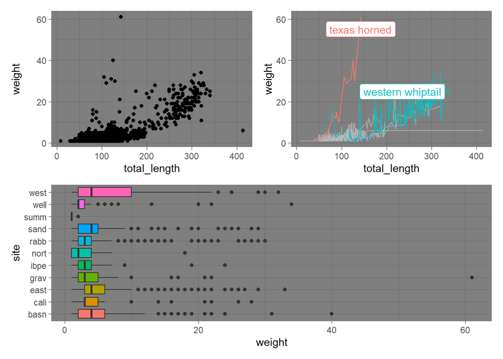

```r
z <- ggplot(data = lizards, aes(y = site, x = weight)) +
  geom_boxplot(aes(fill = site), show.legend = FALSE)

# Put them all together using PEMDAS structure
((p | q) / z) & theme_dark()
```

# 6 Explore some new graph types

## 6.1 Marginal plots

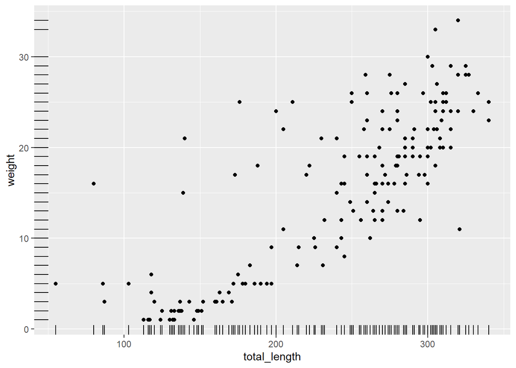

```r
whiptails <- lizards %>%
  filter(common_name == "western whiptail") %>%
  drop_na(total_length, weight)

# An issue with rug plots:
ggplot(data = whiptails, aes(x = total_length, y = weight)) +
  geom_point() +
  geom_rug()
```

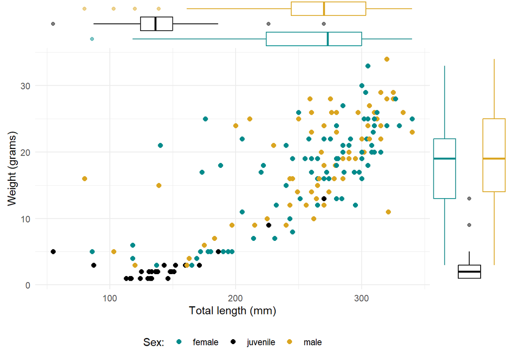

```r
p <- ggplot(data = whiptails, aes(x = total_length, y = weight)) +
  geom_point(aes(color = sex), size = 2) +
  theme_minimal() +
  scale_color_manual(values = c("cyan4", "black", "goldenrod"),
                     name = "Sex:",
                     labels = c("female", "juvenile", "male")
  ) +
  theme(legend.position = "bottom") +
  labs(x = "Total length (mm)",
       y = "Weight (grams)")

# Example 1: A histogram
# ggMarginal(p, type = "histogram", fill = "gray60", color = NA)

# Example 2: A boxplot, grouped by sex (as in the plot)
ggMarginal(p, type = "boxplot", groupColour = TRUE)
```

## 6.2 A beeswarm plot with `ggbeeswarm`

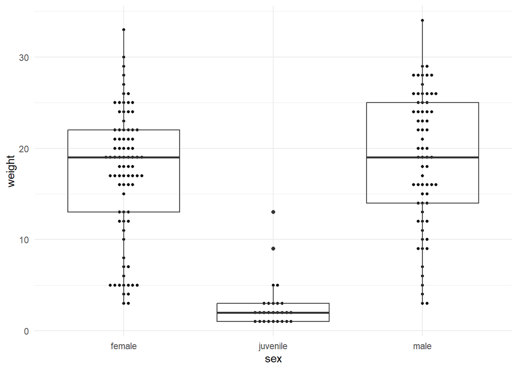

```r
ggplot(data = whiptails, aes(x = sex, y = weight)) +
  geom_beeswarm(size = 1) +
  geom_boxplot(fill = NA) +
  scale_x_discrete(labels = c("female","juvenile","male")) +
  theme_minimal()
```

## 6.3 A heatmap with `geom_tile()`

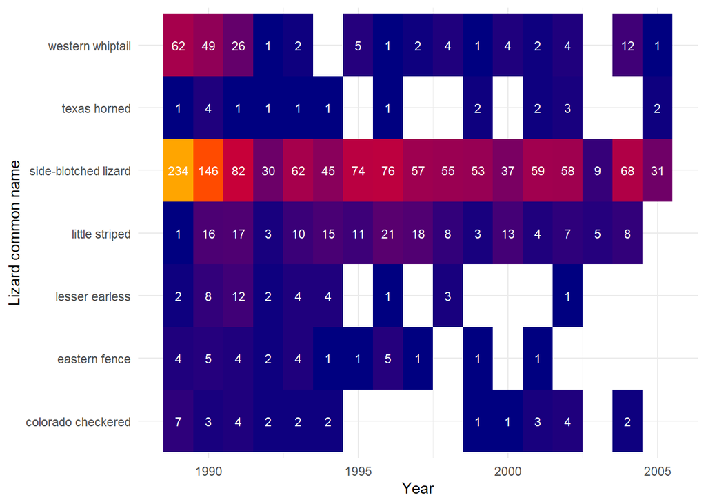

```r
# Get the counts:
lizard_counts <- lizards %>%
  mutate(date = lubridate::mdy(date)) %>%
  count(year = lubridate::year(date), common_name) %>%
  drop_na()

# Make a heatmap of counts:
ggplot(data = lizard_counts, aes(x = year, y = common_name)) +
  geom_tile(aes(fill = n), show.legend = FALSE) +
  geom_text(aes(label = n), color = "white", size = 3) +
  scale_fill_gradientn(colors = c("navy","red","orange")) +
  theme_minimal() +
  labs(x = "Year", y = "Lizard common name")
```

## 6.4 Make a map!

Let’s make a map using some of the skills we’ve learned to customize our ggplots:

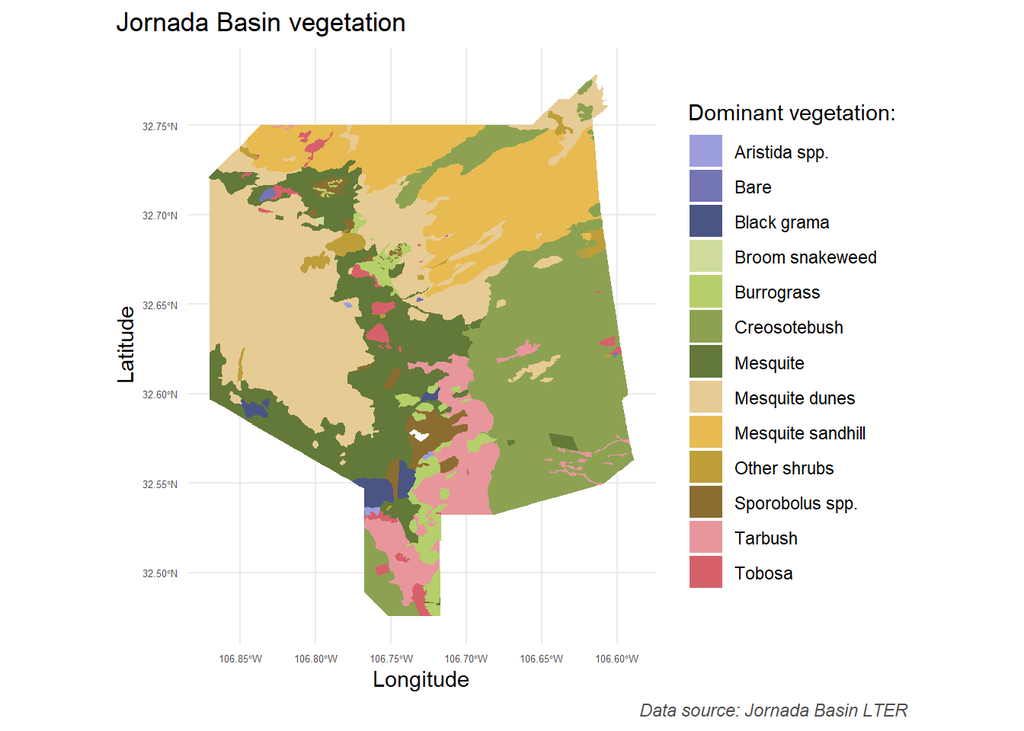

```r
# First, read in the Jornada Basin vegetation data:
jornada_veg <- read_sf(here("data_raw","spatial_vegetation","doc.kml")) %>% dplyr::select(Name) %>%
  clean_names()

# Initial exploratory plot (one plot per attribute)
# plot(jornada_veg)

# Remember, you can see the paletteer palettes with:
# View(palettes_c_names)
# View(palettes_d_names)

ggplot() +
  geom_sf(data = jornada_veg,
          aes(fill = name),
          color = NA) +
  theme_minimal() +
  scale_fill_paletteer_d(palette = "ggthemes::manyeys") +
  labs(x = "Longitude",
       y = "Latitude",
       fill = "Dominant vegetation:",
       title = "Jornada Basin vegetation",
       caption = "Data source: Jornada Basin LTER") +
  theme(legend.position = "right",
        plot.title.position = "plot",
        plot.caption.position = "plot",
        plot.caption = element_text(face = "italic", color = "gray30"),
        axis.text = element_text(size = 5))
```

# 7 Export your graphs & figures

Use `ggsave()` to export your figures, setting the dimensions, dpi, and more. The default in `ggsave()` is to save “the last plot that you displayed, using the size of the current graphics device.”

See `?ggsave` for documentation.

```r
ggsave(filename = "my_awesome_map.png", width = 6, height = 4)
```

# 8 Learn more

Here are some of my favorite resources for building advanced data visualization tools in `ggplot2`, learning about new types of graphs, and choosing an appropriate graph type:

## 8.1 Books

- Claus Wilke’s [*Fundamentals of Data Visualization*](https://clauswilke.com/dataviz/index.html)
- Kieran Healy’s [*Data Visualization*](https://kieranhealy.org/publications/dataviz/)

## 8.2 `ggplot2` tutorials and examples

- [Cedric Scherer](https://twitter.com/CedScherer)’s [“A `ggplot2` tutorial for beautiful plotting in R”](https://www.cedricscherer.com/2019/08/05/a-ggplot2-tutorial-for-beautiful-plotting-in-r/#legends)
- More about [`scales`](https://scales.r-lib.org/)

## 8.3 Data viz inspiration

- [The R Graph Gallery](https://www.r-graph-gallery.com/) by Yan Holtz
- [From Data to Viz](https://www.data-to-viz.com/) by [Yan Holtz](https://twitter.com/R_Graph_Gallery) and [Conor Healy](http://www.conor.fr/indexEN.html)